# IODS course project

**Next, let us standardize the dataset**

```r
Boston_scaled <- scale(Boston)
Boston_scaled <- as.data.frame(Boston_scaled)
summary(Boston_scaled)
```

```
##       crim                 zn               indus              chas
##  Min.   :-0.419367   Min.   :-0.48724   Min.   :-1.5563   Min.   :-0.2723
##  1st Qu.:-0.410563   1st Qu.:-0.48724   1st Qu.:-0.8668   1st Qu.:-0.2723
##  Median :-0.390280   Median :-0.48724   Median :-0.2109   Median :-0.2723
##  Mean   : 0.000000   Mean   : 0.00000   Mean   : 0.0000   Mean   : 0.0000
##  3rd Qu.: 0.007389   3rd Qu.: 0.04872   3rd Qu.: 1.0150   3rd Qu.:-0.2723
##  Max.   : 9.924110   Max.   : 3.80047   Max.   : 2.4202   Max.   : 3.6648
##       nox                rm               age               dis
##  Min.   :-1.4644   Min.   :-3.8764   Min.   :-2.3331   Min.   :-1.2658
##  1st Qu.:-0.9121   1st Qu.:-0.5681   1st Qu.:-0.8366   1st Qu.:-0.8049
##  Median :-0.1441   Median :-0.1084   Median : 0.3171   Median :-0.2790
##  Mean   : 0.0000   Mean   : 0.0000   Mean   : 0.0000   Mean   : 0.0000
##  3rd Qu.: 0.5981   3rd Qu.: 0.4823   3rd Qu.: 0.9059   3rd Qu.: 0.6617
##  Max.   : 2.7296   Max.   : 3.5515   Max.   : 1.1164   Max.   : 3.9566
##       rad               tax             ptratio            black
##  Min.   :-0.9819   Min.   :-1.3127   Min.   :-2.7047   Min.   :-3.9033
##  1st Qu.:-0.6373   1st Qu.:-0.7668   1st Qu.:-0.4876   1st Qu.: 0.2049
##  Median :-0.5225   Median :-0.4642   Median : 0.2746   Median : 0.3808
##  Mean   : 0.0000   Mean   : 0.0000   Mean   : 0.0000   Mean   : 0.0000
##  3rd Qu.: 1.6596   3rd Qu.: 1.5294   3rd Qu.: 0.8058   3rd Qu.: 0.4332
##  Max.   : 1.6596   Max.   : 1.7964   Max.   : 1.6372   Max.   : 0.4406
##      lstat              medv
##  Min.   :-1.5296   Min.   :-1.9063
##  1st Qu.:-0.7986   1st Qu.:-0.5989
##  Median :-0.1811   Median :-0.1449
##  Mean   : 0.0000   Mean   : 0.0000
##  3rd Qu.: 0.6024   3rd Qu.: 0.2683
##  Max.   : 3.5453   Max.   : 2.9865
```

In the standardized dataset, the mean of each variable should be very close to 0, which seems correct by our summary. This also implies that the standard deviation of each variable should be close to 1.

**Next,We do the following: Create a categorical variable of the crime rate in the Boston dataset (from the scaled crime rate). Use the quantiles as the break points in the categorical variable. Drop the old crime rate variable from the dataset. Divide the dataset to train and test sets, so that 80% of the data belongs to the train set.**

```r
crime_quantiles <- quantile(Boston_scaled[, "crim"])
Boston_scaled$crime_cat <- cut(Boston_scaled[, "crim"], breaks = crime_quantiles, include.lowest = TRUE, labels = FALSE)

# Drop the old crime rate variable
Boston_scaled$crim <- NULL

install.packages("caTools")
library(caTools)
# Splitting the dataset into train and test sets
set.seed(123)  # Setting seed for reproducibility
split <- sample.split(Boston_scaled, SplitRatio = 0.8)  # Splitting
train_set <- subset(Boston_scaled, split == TRUE)  # 80% for training
test_set <- subset(Boston_scaled, split == FALSE)  # 20% for testing
```

Now we have created the test set and the train set. **NExt, we fit the linear discriminant analysis on the train set:**

```r
lda_model <- lda(crime_cat ~ ., data = train_set)
print(lda_model)
```

```
## Call:
## lda(crime_cat ~ ., data = train_set)
##
## Prior probabilities of groups:
##         1         2         3         4
## 0.2487437 0.2537688 0.2462312 0.2512563
##
## Group means:
##           zn      indus        chas        nox         rm        age        dis
## 1  0.9571563 -0.9128592 -0.07348562 -0.8749222  0.4358624 -0.8738589  0.9042847
## 2 -0.1270298 -0.2514731 -0.03844192 -0.5650634 -0.1582777 -0.3891141  0.3305265
## 3 -0.3804849  0.1833750  0.24993933  0.4047974  0.1464180  0.4758085 -0.3724963
## 4 -0.4872402  1.0171519 -0.03610305  1.0728118 -0.3787474  0.8348153 -0.8576564
##          rad        tax     ptratio       black        lstat        medv
## 1 -0.7057751 -0.7561490 -0.44416554  0.38231109 -0.765572825  0.52668332
## 2 -0.5565973 -0.4677967 -0.04851787  0.34306993 -0.153219847 -0.01573186
## 3 -0.4275601 -0.3229011 -0.30326583  0.04969264 -0.005758873  0.16562998
## 4  1.6377820  1.5138081  0.78037363 -0.72434339  0.882058886 -0.71716121
##
## Coefficients of linear discriminants:
##                  LD1         LD2         LD3
## zn       0.083062338  0.66201394 -1.02636397
## indus    0.046215842 -0.18394575  0.31434898
## chas    -0.111398646 -0.01334864  0.02631853
## nox      0.334352217 -0.82754017 -1.18586343
## rm      -0.109492585 -0.10365683 -0.17007976
## age      0.294574324 -0.46196563 -0.42597863
## dis     -0.032506167 -0.31732838 -0.01701235
## rad      3.423554045  0.86910593 -0.17987617
## tax      0.002905467  0.05865570  0.60678890
## ptratio  0.083078496  0.03600063 -0.30013587
## black   -0.077883429  0.03383353  0.16878604
## lstat    0.214422789 -0.12956856  0.36397272
## medv     0.189930282 -0.36847262 -0.18211656
##
## Proportion of trace:
##    LD1    LD2    LD3
## 0.9510 0.0351 0.0139
```

**…And continue by drawing the LDA (bi)plot:**

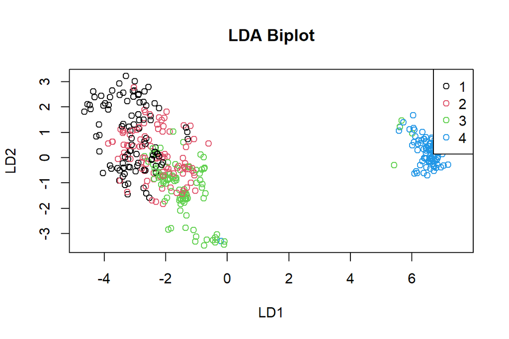

```r
# Extract the scores (LD1 and LD2)
lda_scores <- predict(lda_model)$x

# Create a biplot
plot(lda_scores[,1], lda_scores[,2], col=train_set$crime_cat,
     xlab="LD1", ylab="LD2", main="LDA Biplot")
legend("topright", legend=levels(factor(train_set$crime_cat)),
       col=1:length(levels(factor(train_set$crime_cat))), pch=1)
```

In our biplot, each point represents an observation from our training set. The color of each point corresponds to the category of crime rate. LD1 and LD2 are the first two linear discriminants.

**Next step: Save the crime categories from the test set and then remove the categorical crime variable from the test dataset. Then predict the classes with the LDA model on the test data. Cross tabulate the results with the crime categories from the test set. Comment on the results.**

```r
# Save the crime categories from the test set
actual_crime_categories <- test_set$crime_cat

# Remove the categorical crime variable from the test dataset
test_set$crime_cat <- NULL

# Predict the classes with the LDA model on the test data
predicted_crime_categories <- predict(lda_model, newdata = test_set)$class

# Cross-tabulate the results
confusion_matrix <- table(Predicted = predicted_crime_categories, Actual = actual_crime_categories)

# Print the confusion matrix
print(confusion_matrix)
```

```
##          Actual
## Predicted  1  2  3  4
##         1 15  4  1  0
##         2 11 14  6  0
##         3  2  7 19  0
##         4  0  0  2 27
```

In our cross-tabulation matrix, each row represent the predicted categories of crime rate of our LDA model, while each column represents the actual categories of crime rate from the test set. The diagonal values show the correct predictions for each category. Overall, it seems that quite a substantial number or categories was predicted correctly. Our model seems to perform best in distinguishing the category 4, while in category 1 the was quite a severe number of misclassifications. The category four represents the highest quantile of the crime rates. As there was a clear division between suburbs with low crime rates and suburbs with extremely high crime rates, this makes sense. It seems that there are several predictors that point towards the high crime rate, which makes it easy to predict.

**Next: Reload the Boston dataset and standardize the dataset. Calculate the distances between the observations. Run k-means algorithm on the dataset. Investigate what is the optimal number of clusters and run the algorithm again. Visualize the clusters (for example with the pairs() or ggpairs() functions, where the clusters are separated with colors) and interpret the results**

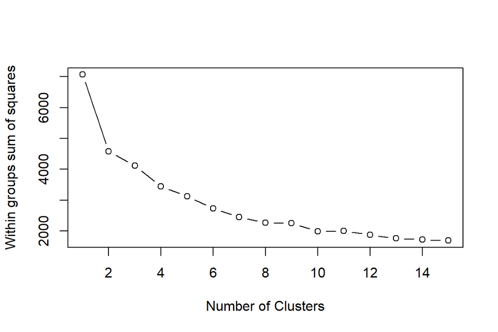

```r
library(MASS)  # Load the MASS package for the Boston dataset
data("Boston")  # Load the Boston dataset

# Standardize the dataset
Boston_scaled <- scale(Boston)
# Calculate the distances between observations
distances <- dist(Boston_scaled)
# Set a seed for reproducibility
set.seed(123)

# Run the k-means algorithm with an arbitrary number of clusters, e.g., 3
initial_kmeans <- kmeans(Boston_scaled, centers = 3, nstart = 25)

# We find the optimal number of clusters by the "elbow" method

wss <- (nrow(Boston_scaled)-1)*sum(apply(Boston_scaled,2,var))
for (i in 2:15) wss[i] <- sum(kmeans(Boston_scaled, centers=i)$withinss)

plot(1:15, wss, type="b", xlab="Number of Clusters", ylab="Within groups sum of squares")
```

In the elbow method, we want to choose the number of clusters where the rate of decrease sharply changes. Beyond this point, adding more clusters would not change the results that much. While we dont have very clear “elbow” in the picture, I will choose 8 clusters, after which the decrease is significantly lower.

Let us run the algorithm again with optimal number of clusters an visualize them:

[figure not shown]

```r
optimal_kmeans <- kmeans(Boston_scaled, centers = 8, nstart = 25)

pairs(Boston_scaled, col = optimal_kmeans$cluster)
```

OKay, the pairs() function looks absolutely horrible. The colors in the graph should be pointing towards each of the category. I literally cannot see any correlations in the pairs function because the picture is so bad. There most like would be a better way of doing this, but I’m out of ideas.

# Exercise 5

```r
date()
```

```
## [1] "Mon Dec 11 19:50:07 2023"
```

In this exercise, we analyse the data from UN which examines the Human Development Index (HDI), an index that assess the development of countries beyond the sole GDP growth.

```r
library(readr)
human <- read_csv("data/human.csv",show_col_types = FALSE)
```

First, we change the row numbers to country names:

```r
 Human_new <- human[,-1]
rownames(Human_new) <- human$Country
```

Next, let us examine our data graphically:

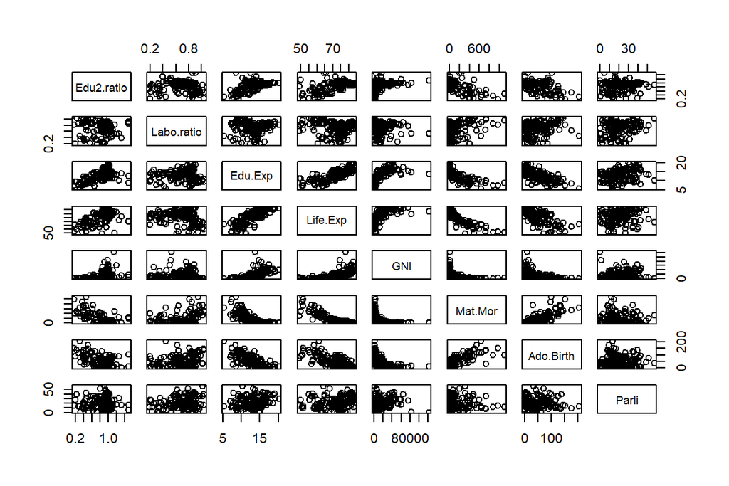

```r
# Scatterplot matrix for numeric variables
pairs(Human_new)
```

From our graphical presentation, we can see some clear correlations of the variables. Maternal mortality and adolescent birth rate are clearly decreasing in Gross National Income GNI. Also the expectancy of education decreases the maternal mortality and adolescent birth rate. Life expectancy and Education rate clearly increases in GNI.

```r
summary(Human_new)
```

```
##    Edu2.ratio       Labo.ratio        Edu.Exp         Life.Exp
##  Min.   :0.1717   Min.   :0.1857   Min.   : 5.40   Min.   :49.00
##  1st Qu.:0.7264   1st Qu.:0.5984   1st Qu.:11.25   1st Qu.:66.30
##  Median :0.9375   Median :0.7535   Median :13.50   Median :74.20
##  Mean   :0.8529   Mean   :0.7074   Mean   :13.18   Mean   :71.65
##  3rd Qu.:0.9968   3rd Qu.:0.8535   3rd Qu.:15.20   3rd Qu.:77.25
##  Max.   :1.4967   Max.   :1.0380   Max.   :20.20   Max.   :83.50
##       GNI            Mat.Mor         Ado.Birth          Parli
##  Min.   :   581   Min.   :   1.0   Min.   :  0.60   Min.   : 0.00
##  1st Qu.:  4198   1st Qu.:  11.5   1st Qu.: 12.65   1st Qu.:12.40
##  Median : 12040   Median :  49.0   Median : 33.60   Median :19.30
##  Mean   : 17628   Mean   : 149.1   Mean   : 47.16   Mean   :20.91
##  3rd Qu.: 24512   3rd Qu.: 190.0   3rd Qu.: 71.95   3rd Qu.:27.95
##  Max.   :123124   Max.   :1100.0   Max.   :204.80   Max.   :57.50
```

The variables Edu2.ratio and Labo.ratio presents the ratio of female populations vs male populations with secondary education and in labor force, respectively. We see that at minimum, there are five males with secondary education and in labor for each female. Parli is the percentage of female representatives in parliament, with a shocking minimum of 0%.

**Next, we perform the PCA analysis on the human data.** The PCA analysis is a way to reduce the dimensions of the dataset without sacrificing important information.

```r
pca_result <- prcomp(Human_new, scale. = FALSE)  # Scale. = FALSE , because our data is not standardized

# Summary of PCA results
summary(pca_result)
```

```
## Importance of components:
##                              PC1      PC2   PC3   PC4   PC5   PC6    PC7    PC8
## Standard deviation     1.854e+04 185.5219 25.19 11.45 3.766 1.566 0.1912 0.1591
## Proportion of Variance 9.999e-01   0.0001  0.00  0.00 0.000 0.000 0.0000 0.0000
## Cumulative Proportion  9.999e-01   1.0000  1.00  1.00 1.000 1.000 1.0000 1.0000
```

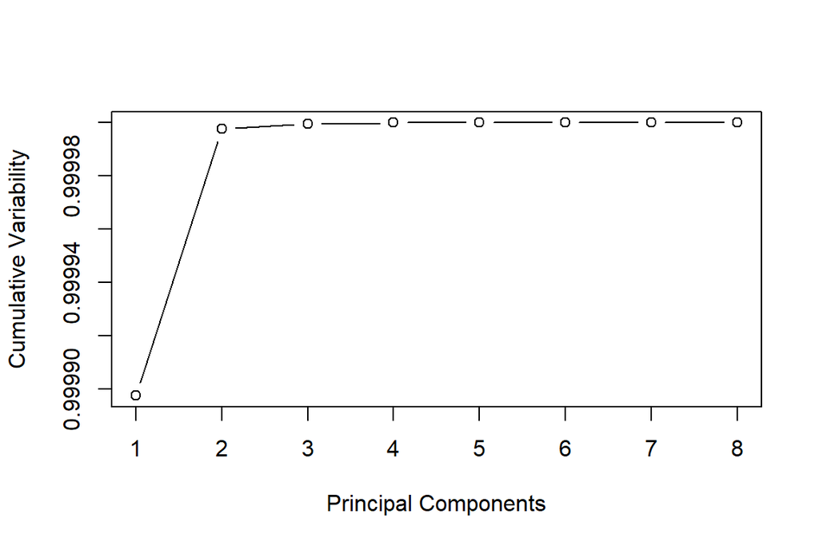

```r
# Variability captured by principal components
cumulative_variability <- cumsum(pca_result$sdev^2) / sum(pca_result$sdev^2)

# Plot cumulative variability
plot(cumulative_variability, type = "b", xlab = "Principal Components", ylab = "Cumulative Variability")
```

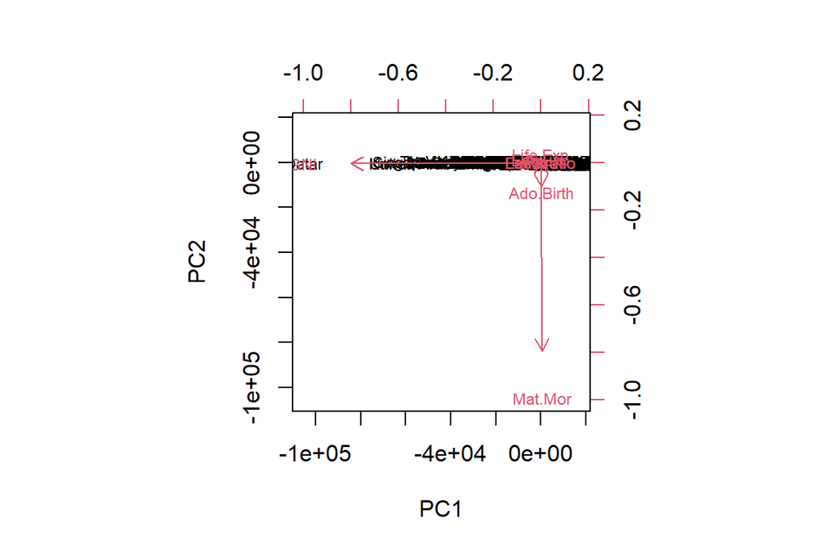

```r
# Biplot
biplot(pca_result, scale = 0, cex = 0.7)
```

It seems that the Principal Component 1 explains almost all the variability in our data. Let us check how the variables are loaded in PC1:

```r
loadings <- pca_result$rotation
print(loadings[, 1:1])
```

```
##    Edu2.ratio    Labo.ratio       Edu.Exp      Life.Exp           GNI
## -5.607472e-06  2.331945e-07 -9.562910e-05 -2.815823e-04 -9.999832e-01
##       Mat.Mor     Ado.Birth         Parli
##  5.655734e-03  1.233961e-03 -5.526460e-05
```

Seems like GNI has very strong inverse relationship with PC1, implying that it strongly contributes to the variance captured by PC1. Next, let us standardize the Human_new data and repeat the analysis:

```r
standardized_data <- scale(Human_new)

pca_result_standardized <- prcomp(standardized_data)

# Summary of PCA results on standardized data
summary(pca_result_standardized)
```

```
## Importance of components:
##                           PC1    PC2     PC3     PC4     PC5     PC6     PC7
## Standard deviation     2.0708 1.1397 0.87505 0.77886 0.66196 0.53631 0.45900
## Proportion of Variance 0.5361 0.1624 0.09571 0.07583 0.05477 0.03595 0.02634
## Cumulative Proportion  0.5361 0.6984 0.79413 0.86996 0.92473 0.96069 0.98702
##                            PC8
## Standard deviation     0.32224
## Proportion of Variance 0.01298
## Cumulative Proportion  1.00000
```

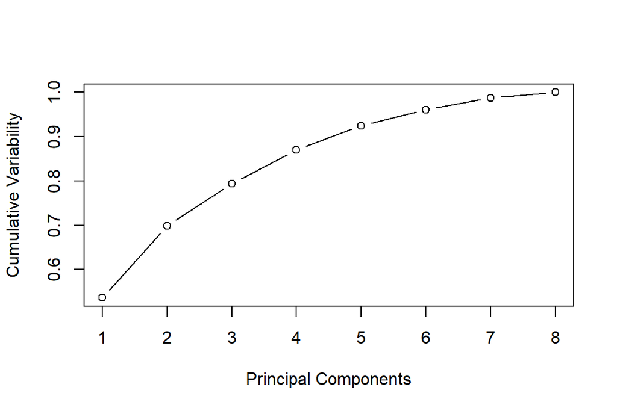

```r
# Variability captured by principal components on standardized data
cumulative_variability_standardized <- cumsum(pca_result_standardized$sdev^2) / sum(pca_result_standardized$sdev^2)

# Plot cumulative variability on standardized data
plot(cumulative_variability_standardized, type = "b", xlab = "Principal Components", ylab = "Cumulative Variability")
```

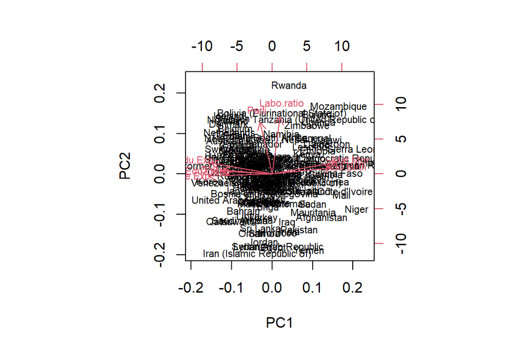

```r
# Biplot on standardized data
biplot(pca_result_standardized, cex = 0.7)
```

Now it seems based on the biplot that other variables than GNI also contributes to our data variance. Let us create some graphs to compare the two results:

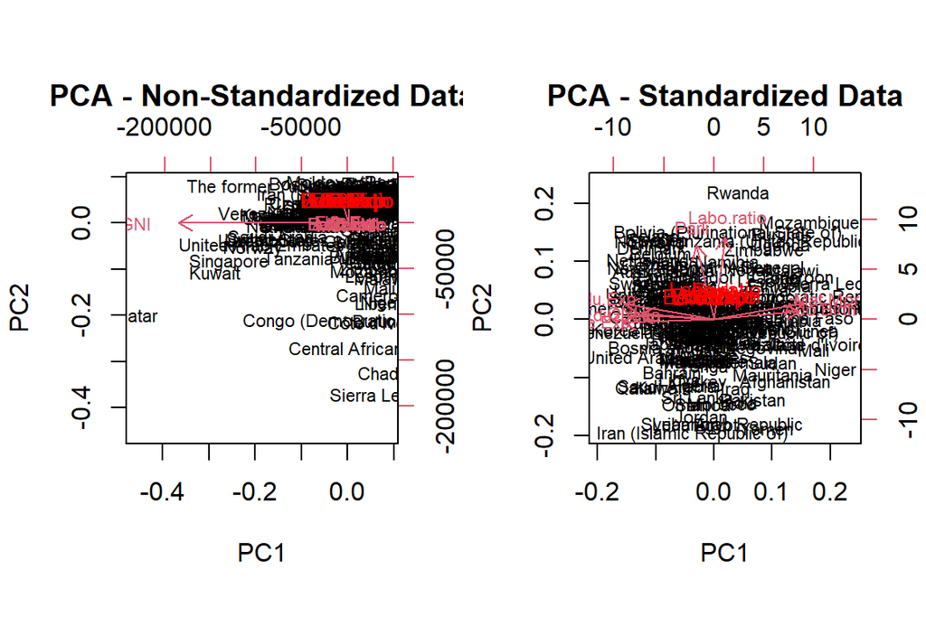

```r
library(ggplot2)
library(dplyr)
# Perform PCA on non-standardized data
pca_result_non_standardized <- prcomp(Human_new, scale. = FALSE)

# Perform PCA on standardized data
standardized_data <- scale(Human_new)
pca_result_standardized <- prcomp(standardized_data)

# Create side-by-side biplots
par(mfrow = c(1, 2))

# Biplots for non-standardized data
biplot(pca_result_non_standardized, cex = 0.7, main = "PCA - Non-Standardized Data")
text(pca_result_non_standardized$rotation, labels = colnames(Human_new), col = "red", cex = 0.8, pos = 3)

# Biplots for standardized data
biplot(pca_result_standardized, cex = 0.7, main = "PCA - Standardized Data")
text(pca_result_standardized$rotation, labels = colnames(Human_new), col = "red", cex = 0.8, pos = 3)
```

Clearly, looking back to the summary of our dataset, the GNI observations are so large that it overrules all other variables when the data is not standardized. Here we have a wonderful example of how important it is to standardize the dataset in order to be able to really compare the variables and their effects.

In the biplot created with the standardized dataset, we can see that the variables “parli” and “labo.ratio” share the vector length and direction. This is intuitive: higher number of female in the workforce correlated with a higher percentage of female in the parliament. Also life expectancy, education expectancy and the ratio of female with at least secondary education correlate.

**Now, we jump to a TEA data!**

```r
tea <- read.csv("https://raw.githubusercontent.com/KimmoVehkalahti/Helsinki-Open-Data-Science/master/datasets/tea.csv", stringsAsFactors = TRUE)
tea$age <- as.factor(tea$age)
View(tea)
```

In tea data we have a questionnare of 300 individuals that were asked how they drink their tea. I changed the “age” variable to a factor variable. Let us perform a MCA analysis on the tea data:

```r
install.packages("FactoMineR")
library(FactoMineR)
mca_result <- MCA(tea)
```

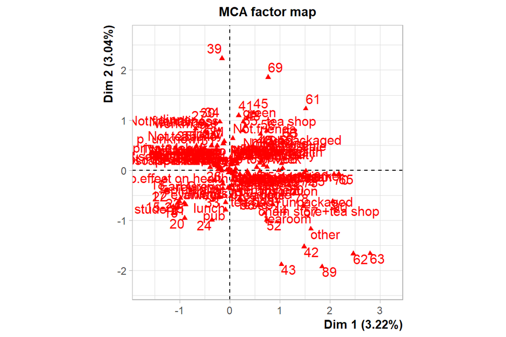

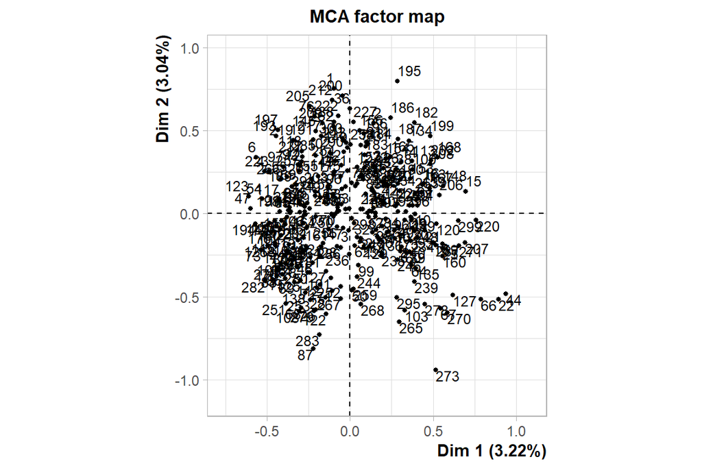

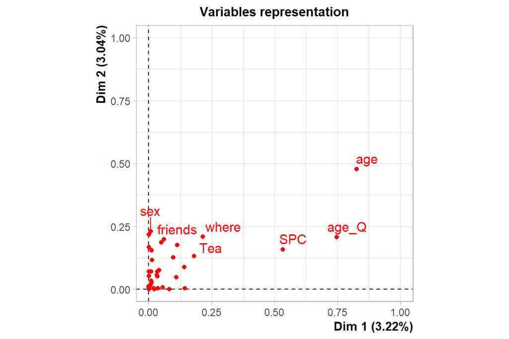

```r
summary(mca_result)
```

```
##
## Call:
## MCA(X = tea)
##
##
## Eigenvalues
##                        Dim.1   Dim.2   Dim.3   Dim.4   Dim.5   Dim.6   Dim.7
## Variance               0.102   0.096   0.085   0.076   0.066   0.065   0.063
## % of var.              3.217   3.038   2.686   2.413   2.083   2.063   2.003
## Cumulative % of var.   3.217   6.255   8.941  11.353  13.436  15.499  17.502
##                        Dim.8   Dim.9  Dim.10  Dim.11  Dim.12  Dim.13  Dim.14
## Variance               0.060   0.056   0.055   0.052   0.050   0.049   0.047
## % of var.              1.890   1.755   1.732   1.651   1.594   1.542   1.496
## Cumulative % of var.  19.392  21.147  22.879  24.530  26.124  27.666  29.162
##                       Dim.15  Dim.16  Dim.17  Dim.18  Dim.19  Dim.20  Dim.21
## Variance               0.047   0.046   0.044   0.044   0.043   0.041   0.040
## % of var.              1.481   1.444   1.403   1.376   1.349   1.297   1.266
## Cumulative % of var.  30.643  32.088  33.491  34.867  36.216  37.512  38.778
##                       Dim.22  Dim.23  Dim.24  Dim.25  Dim.26  Dim.27  Dim.28
## Variance               0.040   0.039   0.039   0.037   0.037   0.036   0.036
## % of var.              1.250   1.221   1.218   1.181   1.155   1.146   1.142
## Cumulative % of var.  40.028  41.249  42.467  43.648  44.802  45.948  47.090
##                       Dim.29  Dim.30  Dim.31  Dim.32  Dim.33  Dim.34  Dim.35
## Variance               0.035   0.035   0.035   0.033   0.033   0.033   0.033
## % of var.              1.115   1.104   1.090   1.053   1.042   1.038   1.026
## Cumulative % of var.  48.206  49.310  50.400  51.452  52.494  53.533  54.559
##                       Dim.36  Dim.37  Dim.38  Dim.39  Dim.40  Dim.41  Dim.42
## Variance               0.032   0.031   0.031   0.030   0.030   0.030   0.030
## % of var.              1.001   0.985   0.978   0.957   0.951   0.943   0.940
## Cumulative % of var.  55.560  56.545  57.523  58.480  59.430  60.374  61.314
##                       Dim.43  Dim.44  Dim.45  Dim.46  Dim.47  Dim.48  Dim.49
## Variance               0.030   0.029   0.029   0.029   0.029   0.029   0.028
## % of var.              0.935   0.922   0.920   0.915   0.909   0.906   0.896
## Cumulative % of var.  62.249  63.171  64.091  65.006  65.915  66.821  67.717
##                       Dim.50  Dim.51  Dim.52  Dim.53  Dim.54  Dim.55  Dim.56
## Variance               0.028   0.028   0.028   0.028   0.028   0.028   0.028
## % of var.              0.891   0.886   0.885   0.884   0.880   0.877   0.877
## Cumulative % of var.  68.608  69.494  70.379  71.263  72.142  73.020  73.897
##                       Dim.57  Dim.58  Dim.59  Dim.60  Dim.61  Dim.62  Dim.63
## Variance               0.028   0.028   0.028   0.028   0.027   0.026   0.026
```

[output cut: 80 more lines]

```
## dinner         0.339  0.263  0.009  1.609 |
## Not.dinner    -0.026  0.020  0.009 -1.609 |
##
## Categorical variables (eta2)
##                 Dim.1 Dim.2 Dim.3
## breakfast     | 0.007 0.014 0.002 |
## tea.time      | 0.050 0.185 0.000 |
## evening       | 0.034 0.071 0.043 |
## lunch         | 0.001 0.071 0.004 |
## dinner        | 0.035 0.051 0.009 |
## always        | 0.010 0.070 0.012 |
## home          | 0.007 0.019 0.012 |
## work          | 0.001 0.052 0.137 |
## tearoom       | 0.114 0.175 0.065 |
## friends       | 0.002 0.218 0.032 |
```

MCA is an extension of Principal Component Analysis (PCA) designed for categorical variables. We can see that the strongest factors affecting to our results are age and SPC, which tells the work rank of the repondent. Other variables conrtibuting to the variance are the place where tea is enjoyed, the brand, sex, and whether friends drink tea or not.

# Exercise 6

```r
date()
```

```
## [1] "Mon Dec 11 19:50:14 2023"
```

In the first part of the exercise 6, we study some data from a nutrition study conducted in three groups of rats (Crowder and Hand, 1990). The three groups were put on different diets, and each animal’s body weight (grams) was recorded repeatedly (approximately weekly, except in week seven when two recordings were taken) over a 9-week period.

```r
library(tidyr); library(dplyr); library(ggplot2)
library(readr)
RATSL <- read_csv("data/RATSL.csv")
RATSL$Group <- factor(RATSL$Group)
RATSL$ID <- factor(RATSL$ID)
glimpse(RATSL)
```

```
## Rows: 176
## Columns: 5
## $ ID     <fct> 1, 2, 3, 4, 5, 6, 7, 8, 9, 10, 11, 12, 13, 14, 15, 16, 1, 2, 3,…
## $ Group  <fct> 1, 1, 1, 1, 1, 1, 1, 1, 2, 2, 2, 2, 3, 3, 3, 3, 1, 1, 1, 1, 1, …
## $ WD     <chr> "WD1", "WD1", "WD1", "WD1", "WD1", "WD1", "WD1", "WD1", "WD1", …
## $ Weight <dbl> 240, 225, 245, 260, 255, 260, 275, 245, 410, 405, 445, 555, 470…
## $ Time   <dbl> 1, 1, 1, 1, 1, 1, 1, 1, 1, 1, 1, 1, 1, 1, 1, 1, 8, 8, 8, 8, 8, …
```

```r
head(RATSL)
```

```
## # A tibble: 6 × 5
##   ID    Group WD    Weight  Time
##   <fct> <fct> <chr>  <dbl> <dbl>
## 1 1     1     WD1      240     1
## 2 2     1     WD1      225     1
## 3 3     1     WD1      245     1
## 4 4     1     WD1      260     1
## 5 5     1     WD1      255     1
## 6 6     1     WD1      260     1
```

```r
tail(RATSL)
```

```
## # A tibble: 6 × 5
##   ID    Group WD    Weight  Time
##   <fct> <fct> <chr>  <dbl> <dbl>
## 1 11    2     WD64     472    64
## 2 12    2     WD64     628    64
## 3 13    3     WD64     525    64
## 4 14    3     WD64     559    64
## 5 15    3     WD64     548    64
## 6 16    3     WD64     569    64
```

**Let us begin our analysis by plotting the weight development of each individual differentiated by their diet groups:**

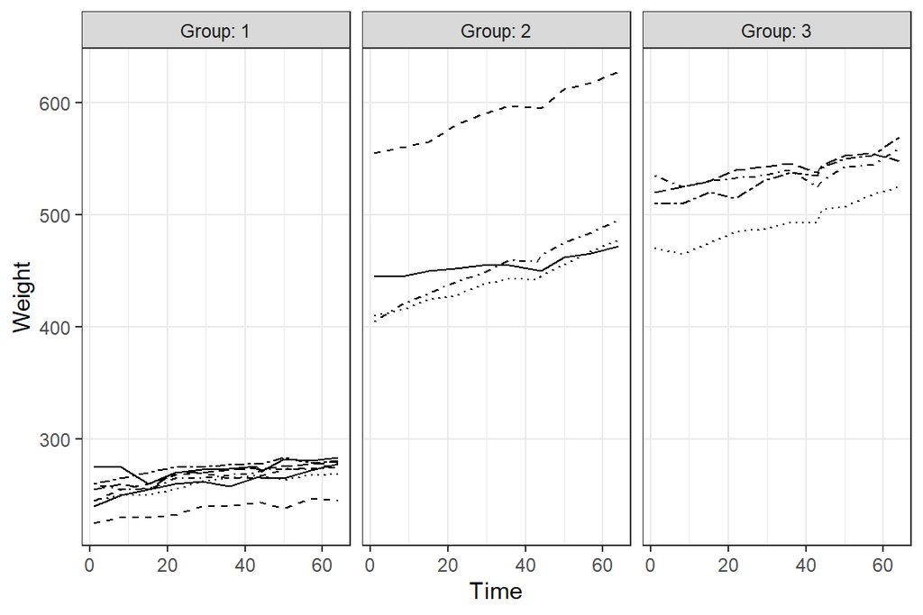

```r
p1 <- ggplot(RATSL, aes(x = Time, y = Weight, linetype = ID))
p2 <- p1 + geom_line() + scale_linetype_manual(values = rep(1:10, times=4))
p3 <- p2 + facet_grid(. ~ Group, labeller = label_both)
p4 <- p3 + theme_bw() + theme(legend.position = "none")
p5 <- p4 + theme(panel.grid.minor.y = element_blank())
p6 <- p5 + scale_y_continuous(limits = c(min(RATSL$Weight), max(RATSL$Weight)))
p6
```

Next, let us standardize the data so that the initial weight does not skew the results:

```r
# Standardise the scores:
RATSL <- RATSL %>%
  group_by(Time) %>%
  mutate( stdweight = (Weight - mean(Weight))/sd(Weight) ) %>%
  ungroup()
glimpse(RATSL)
```

```
## Rows: 176
## Columns: 6
## $ ID        <fct> 1, 2, 3, 4, 5, 6, 7, 8, 9, 10, 11, 12, 13, 14, 15, 16, 1, 2,…
## $ Group     <fct> 1, 1, 1, 1, 1, 1, 1, 1, 2, 2, 2, 2, 3, 3, 3, 3, 1, 1, 1, 1, …
## $ WD        <chr> "WD1", "WD1", "WD1", "WD1", "WD1", "WD1", "WD1", "WD1", "WD1…
## $ Weight    <dbl> 240, 225, 245, 260, 255, 260, 275, 245, 410, 405, 445, 555, …
## $ Time      <dbl> 1, 1, 1, 1, 1, 1, 1, 1, 1, 1, 1, 1, 1, 1, 1, 1, 8, 8, 8, 8, …
## $ stdweight <dbl> -1.0011429, -1.1203857, -0.9613953, -0.8421525, -0.8819001, …
```

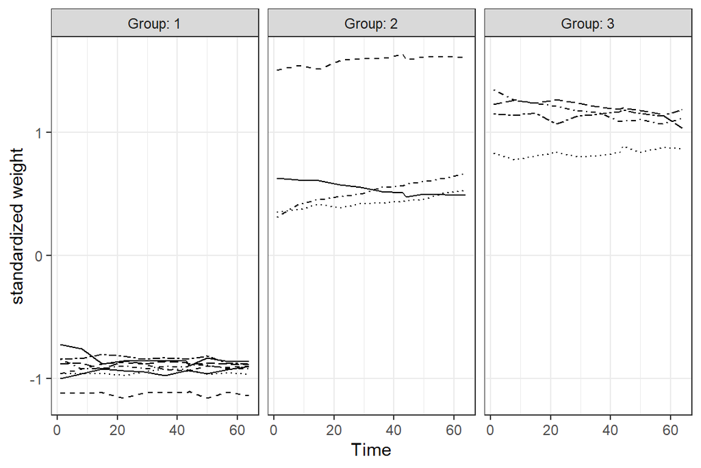

```r
p1 <- ggplot(RATSL, aes(x = Time, y = stdweight, linetype = ID))
p2 <- p1 + geom_line() + scale_linetype_manual(values = rep(1:10, times=4))
p3 <- p2 + facet_grid(. ~ Group, labeller = label_both)
p4 <- p3 + theme_bw() + theme(legend.position = "none")
p5 <- p4 + theme(panel.grid.minor.y = element_blank())
p6 <- p5 + scale_y_continuous(name = "standardized weight")
p6
```

Here are the standardized datapoints graphed. Now I have to stop and focus on my 32-hours old, first-born baby. Thank you for the course!